# Computer Practical 3

Author

Ms. Jem Marie M. Nario

Published

March 5, 2024

**Warning**

Do not change or edit anything in this portion. The portion with the “Assignment Questions” is where you start answering the questions.

# Introduction - read this first!

Please note:

Simply showing the results is not enough. You have to include the script leading to an output and/or explain how you arrived at the results.

## Practice files

On AnimoSpace, you will find the practice file(s) for each computer practical that will be applied in a given assignment.

## Before you get started

Do not dive straight into the assignments, but first read through the entire assignment and try to fathom its intention. Using these assignments as simple point-and-click exercises reduces the whole practical to wasting time. Building a routine for executing and, in particular, interpreting the results of the tests in the assignments is key to the successful completion of the course.

Keep in mind when you answer the questions: What was the null hypothesis? Is the test significant? What exactly does the result demonstrate? How would you phrase the conclusion in your own words? Running statistical tests is pointless without a thorough insight into what the results do (and do not) imply. Make sure to familiarize yourself with understanding, interpreting, and discussing the results you get from your analyses (and be aware that we will also expect you to do so in the final essay).

Below, you find the instructions for the first assignment and the questions you must answer. These questions are followed by the word **[ANSWER].** You must provide your answer there. Depending on the question, you will have to write in plain text or add a *chunk* to insert the code, allowing you to answer the question and then render this Quarto document.

On top of providing an answer to the questions after the word **[ANSWER]**, you must also execute the chunks of code provided with the assignments and adapt them when needed (for instance, when setting the working directory at the beginning of each assignment).

Notice that rendering a Quarto document works successfully only when there are no mistakes in the code. Errors are common when coding, and there is no need to be afraid or panic when they occur. When this happens, read the error output to identify what might be the mistake (you can also use Google to understand this). Common mistakes involve forgetting brackets, quotation marks and / or commas, as well as referring to a variable, function or dataset with the wrong name or which has not been defined before.

Remember that a Quarto document acts as a self-contained session: it focuses solely on the content within the document itself and it is important to make sure that all the packages, variables, dataset and other objects that are used within the session are correctly loaded from the document itself (so, a package, variable or dataset present in the global environment which is not loaded from the document itself cannot be used). For this reason, before rendering your Quarto document, make sure to verify that the codes are coherent from the beginning to the end of the document. We highly recommend allocating enough time to each assignment.

Last but not least, functions and tools in R are generally introduced before you are asked to use them. The assignments will typically require a function that has already been introduced and explained before, so you could answer the coding questions referring to what we have seen in previous assignments. If you want to expand your skills and range of functions, feel free to look for other ways on the Internet, but make sure you understand their documentation and way of working.

## Installing R packages

```r
# Install packages that are not yet installed
if(!("tidyverse" %in% installed.packages()[,"Package"])) install.packages("tidyverse")
if(!("boot" %in% installed.packages()[,"Package"])) install.packages("boot")
library(readxl)
```

**Important**

For you to get a 1 in this Computer Practical, you must get 20 points out of 45 points.

# Assignment Questions:

## 1. [10 Points]

In the lecture, the bootstrapping done was for the R-squared, but, for this Computer Practical, you need to find the mean for bootstrapping, also, show the plot and the Confidence Intervals.

#### Sample:

```r
set.seed(123)
library(boot)
mean_function <- function(formula, data, indices){
 d<-data[indices,]
 fit<-lm(formula, data=d)
 return(coef(fit))
}
reps<-boot(data=mtcars, statistic=mean_function, R=3000, formula=mpg~disp)
reps
```

```
ORDINARY NONPARAMETRIC BOOTSTRAP


Call:
boot(data = mtcars, statistic = mean_function, R = 3000, formula = mpg ~
    disp)


Bootstrap Statistics :
       original        bias    std. error
t1* 29.59985476 -6.355702e-02 1.484029478
t2* -0.04121512  4.150206e-06 0.005163777
```

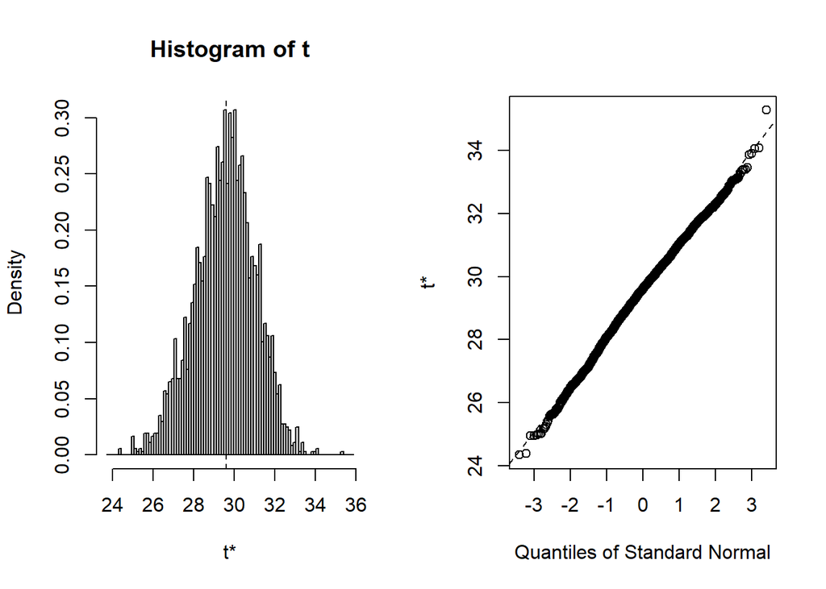

```r
plot(reps)
```

Let’s run the regression to see if the average mean for mpg and disp would be the same;

```r
model<-lm(mpg~disp, data=mtcars)
summary(model)
```

```
Call:
lm(formula = mpg ~ disp, data = mtcars)

Residuals:
    Min      1Q  Median      3Q     Max
-4.8922 -2.2022 -0.9631  1.6272  7.2305

Coefficients:
             Estimate Std. Error t value Pr(>|t|)
(Intercept) 29.599855   1.229720  24.070  < 2e-16 ***
disp        -0.041215   0.004712  -8.747 9.38e-10 ***
---
Signif. codes:  0 '***' 0.001 '**' 0.01 '*' 0.05 '.' 0.1 ' ' 1

Residual standard error: 3.251 on 30 degrees of freedom
Multiple R-squared:  0.7183,    Adjusted R-squared:  0.709
F-statistic: 76.51 on 1 and 30 DF,  p-value: 9.38e-10
```

Now, try it on your own with the wage dataset found in Computer Practical 1. You have to bootstrap with 3000 replications the mean of the following formula: `wage=educ+exper+tenure`. Plot the results and get the confidence intervals using `bca`.

#### **[ANSWER]**

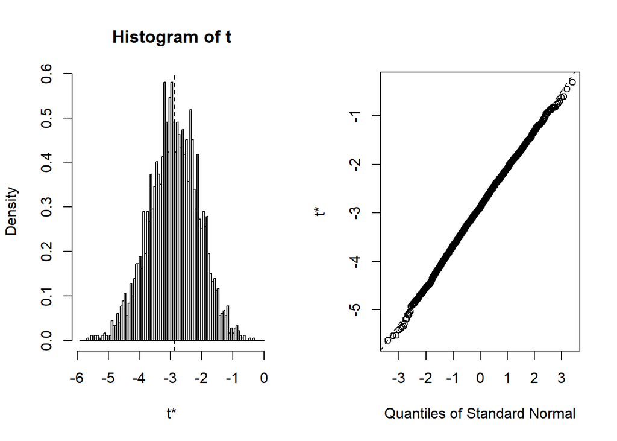

```r
wage <- read_excel("wage.xlsx")

set.seed(123)

mean_function <- function(formula, data, indices) {
  d <- data[indices, ]
  fit <- lm(formula, data = d)
  return(coef(fit))
}

reps <- boot(data = wage, statistic = mean_function, R = 3000, formula = wage ~ educ+exper+tenure)


plot(reps)
```

```r
reps$t0
```

```
(Intercept)        educ       exper      tenure
-2.87273489  0.59896507  0.02233952  0.16926865
```

```r
reps
```

```
ORDINARY NONPARAMETRIC BOOTSTRAP


Call:
boot(data = wage, statistic = mean_function, R = 3000, formula = wage ~
    educ + exper + tenure)


Bootstrap Statistics :
       original        bias    std. error
t1* -2.87273489 -1.488190e-02  0.80305371
t2*  0.59896507  9.678445e-04  0.06045675
t3*  0.02233952  2.638446e-05  0.01081065
t4*  0.16926865  2.730880e-04  0.02950450
```

```r
boot.ci(reps, type="bca")
```

```
BOOTSTRAP CONFIDENCE INTERVAL CALCULATIONS
Based on 3000 bootstrap replicates

CALL :
boot.ci(boot.out = reps, type = "bca")

Intervals :
Level       BCa
95%   (-4.507, -1.325 )
Calculations and Intervals on Original Scale
```

This means that the interval spans from -4.507 to -1.325 with confidence level of 95%.

## Hypothesis Testing

The Health Insurance Subsidy Program’s primary objective is to reduce the burden of health-related out-of-pocket expenditures for low income households. The data contains information on out-of-pocket health expenditures (per capita per year) denoted as *health_expenditures*, age, completed years of schooling, and other variables. We are interested in knowing whether the women head of household enrolled in the HISP has reduced health expenditures as compared to men who are head of household enrolled in the HISP.

## 2. [5 Points] Use T-tests

### a.

The dataset was conducted twice; one is the baseline survey and the other is the follow-up survey. Is there significant evidence that the health_expenditures’ means changed?

#### [ANSWER]

The hypotheses:

H0: There is no difference in the means of health expenditures between baseline and follow-up.  
H1: The means of health expenditures are not equal between baseline and follow-up.

We will use **paired t-test** since we are comparing the difference in means from two variables measured on the same set of subjects.

```r
base <- read_excel("hisp.xlsx", sheet = "base")
fllw <- read_excel("hisp.xlsx", sheet = "follow-up")

healthExp_base <- base$health_expenditures
healthExp_fllw <- fllw$health_expenditures[2:9914]

#'The follow-up worksheet has (rows 2-9915) 9914 data points. The last row (9915) was omitted to have the same length as the base.'
```

```r
#t.test(x1, x2, paired=TRUE)
t.test(healthExp_base, healthExp_fllw, paired=TRUE)
```

```
    Paired t-test

data:  healthExp_base and healthExp_fllw
t = 3.4593, df = 9912, p-value = 0.0005438
alternative hypothesis: true mean difference is not equal to 0
95 percent confidence interval:
 0.1525601 0.5515266
sample estimates:
mean difference
      0.3520433
```

Since the p-value (0.0005438) is less than the significance level (usually 0.05), we reject the null hypothesis. There is significant evidence to conclude that the means of health expenditures changed between baseline and follow-up.

### b.

Using the base survey (worksheet name: base)

Find the separate fractions of men and women that are classified as enrolled in HISP (*enrolled)*. Are more people enrolled in HISP or not?

#### [ANSWER]

```r
# Read the data from the Excel sheet into R
base_data <- read_excel("hisp.xlsx", sheet = "base")

# Creating subsets + counting the total number of men/women
total_men <- sum(base_data$female_hh == 0)
total_women <- sum(base_data$female_hh == 1)

# Total men+women
total_all <- total_men + total_women

# Total enrolled men/women
enrolled_men <- sum(base_data$enrolled[base_data$female_hh == 0])  # Count of enrolled men
enrolled_women <- sum(base_data$enrolled[base_data$female_hh == 1])  # Count of enrolled women

# Total enrolled men/women
total_enrolled <- sum(base_data$enrolled)

# Calculate the proportions
fraction_enrolled_men <- enrolled_men / total_men
fraction_enrolled_women <- enrolled_women / total_women
fraction_enrolled <- total_enrolled / total_all

# Print the fractions
cat("Fraction of enrolled men:", fraction_enrolled_men, "\n")
```

```
Fraction of enrolled men: 0.3075803
```

```r
cat("Fraction of enrolled women:", fraction_enrolled_women, "\n")
```

```
Fraction of enrolled women: 0.2209776
```

```r
cat("Fraction of enrolled people:", fraction_enrolled, "\n\n")
```

```
Fraction of enrolled people: 0.2990013
```

```r
# Compare more people enrolled or not
total_not_enrolled <- nrow(base_data) - total_enrolled

if (fraction_enrolled > 0.5) {
  cat("More people are enrolled in HISP.\n")
} else if (total_enrolled < total_not_enrolled) {
  cat("More people are NOT enrolled in HISP.\n")
} else {
  cat("Equal number of people are enrolled and not enrolled in HISP.\n")
}
```

```
More people are NOT enrolled in HISP.
```

### c.

Test the null hypothesis that the population fractions of enrolled women and men are the same. Find the one-tailed p-value; report the results. What can you infer from the results?

#### [ANSWER]

We will use `alternative = "greater"` to see whether the population fraction of enrolled men is greater than the population fraction of enrolled women.

H0: The population fractions of enrolled women and men are the same.

H1: The population fraction of enrolled men is greater than the population fraction of enrolled women.

```r
prop.test(x=c(enrolled_men, enrolled_women), n=c(total_men, total_women), alternative="greater", correct=FALSE)
```

```
    2-sample test for equality of proportions without continuity correction

data:  c(enrolled_men, enrolled_women) out of c(total_men, total_women)
X-squared = 31.658, df = 1, p-value = 9.194e-09
alternative hypothesis: greater
95 percent confidence interval:
 0.06339056 1.00000000
sample estimates:
   prop 1    prop 2
0.3075803 0.2209776
```

Since the p-value (9.194e-09) is less than the significance level (usually 0.05), we reject the null hypothesis. There is enough evidence to suggest that the population proportion of enrolled men is greater than the population proportion of enrolled women

## Regression with Dummy Variables

## 3.

Consider the following equation:

log(health_expenditures) = B0+B1enrolled+B2age_hh+B3educ_hh+u

where log(health_expenditures) is the per capita out-of-pocket health expenditures; *enrolled* is binary variable where household is enrolled in HISP*; age_hh* is age of the household head*; educ_hh* is completed years of schooling of household head.

### a. [5 points]

What are your expectations for the coefficients in this equation? Which ones do you think will not be significant?

#### [ANSWER]

B0 is a significant term because it represents the level of health expenditure when all other variable is zero.

B1 may not be significant since enrolled people are generally more likely to spend less out-of-pocket health expenditures because of insurance. Although, it may also lead to increase utilization of healthcare services that are not necessarily covered by the insurance. These two contrasting trends may not make B1 significant.

B2 is definitely significant since people generally have higher healthcare needs as they age.

B3 may not be significant. Higher educated people generally have better health awareness; hence, they generally engage in preventive behaviors, reducing health expenditures. On the other hand, higher educated people are also more likely to have higher income. This means better access to healthcare service, which increases health expenditures. These two contrasting trends may not make B3 significant.

### b. [10 points]

Estimate the equation in separately for men and women, and report the results.

#### [ANSWER]

We set first the equations:

```r
# Men
lm_men <- lm(log(health_expenditures) ~ enrolled + age_hh + educ_hh, data = base_data, subset = female_hh == 0)

# Women
lm_women <- lm(log(health_expenditures) ~ enrolled + age_hh + educ_hh, data = base_data, subset = female_hh == 1)
```

```r
# Summary
summary(lm_men)
```

```
Call:
lm(formula = log(health_expenditures) ~ enrolled + age_hh + educ_hh,
    data = base_data, subset = female_hh == 0)

Residuals:
     Min       1Q   Median       3Q      Max
-1.15271 -0.18599  0.04923  0.22918  0.79969

Coefficients:
              Estimate Std. Error t value Pr(>|t|)
(Intercept)  2.4235761  0.0146821  165.07   <2e-16 ***
enrolled    -0.1809166  0.0072426  -24.98   <2e-16 ***
age_hh       0.0073061  0.0002522   28.97   <2e-16 ***
educ_hh      0.0209397  0.0013344   15.69   <2e-16 ***
---
Signif. codes:  0 '***' 0.001 '**' 0.01 '*' 0.05 '.' 0.1 ' ' 1

Residual standard error: 0.3092 on 8927 degrees of freedom
Multiple R-squared:  0.1705,    Adjusted R-squared:  0.1702
F-statistic: 611.6 on 3 and 8927 DF,  p-value: < 2.2e-16
```

All the coefficients are significant since the p-values are less than 0.05. We see here that men who are enrolled spend less out-of-pocket money than men who are enrolled (negative estimate). Meanwhile, we are correct in that people who are older spends more (positive estimate). We also see here than higher educated people also spends more, most likely because of their higher salaries (positive estimate).

```r
# Summary
summary(lm_women)
```

```
Call:
lm(formula = log(health_expenditures) ~ enrolled + age_hh + educ_hh,
    data = base_data, subset = female_hh == 1)

Residuals:
     Min       1Q   Median       3Q      Max
-1.37518 -0.11626  0.05095  0.17931  0.46194

Coefficients:
              Estimate Std. Error t value Pr(>|t|)
(Intercept)  2.5954598  0.0401615  64.626  < 2e-16 ***
enrolled    -0.1718684  0.0197045  -8.722  < 2e-16 ***
age_hh       0.0082804  0.0006291  13.163  < 2e-16 ***
educ_hh      0.0209062  0.0045466   4.598 4.82e-06 ***
---
Signif. codes:  0 '***' 0.001 '**' 0.01 '*' 0.05 '.' 0.1 ' ' 1

Residual standard error: 0.2529 on 978 degrees of freedom
Multiple R-squared:  0.2322,    Adjusted R-squared:  0.2298
F-statistic: 98.58 on 3 and 978 DF,  p-value: < 2.2e-16
```

The same reasoning and analysis can be made for the women; i.e., all coefficients are significant, women who are enrolled spend less in health services, older women spends more, and educated women spends more.

### c. [10 points]

We are interested in finding out whether women and men who are part of an indigenous group, and men who are not part of an indigenous group spend less than women who are not. What have you found? (*Hint: generate interaction terms; reference category: women who are part of an indigenous group)*

#### [ANSWER]

```r
## Generate interaction terms
# non/Indigenous men/women
base_data$nonIn_men <- (base_data$indigenous == 0) * (base_data$female_hh == 0)
base_data$nonIn_women <- (base_data$indigenous == 0) * (base_data$female_hh == 1)
base_data$indigenous_men <- base_data$indigenous * (base_data$female_hh == 0)
# Creating another variables for (1 = non-indigenous, 1 = men)
base_data$nonIn <- ifelse(base_data$indigenous == 0, 1, 0)
base_data$men <- ifelse(base_data$female_hh == 0, 1, 0)

# Estimate the equation with interaction terms
lm_1 <- lm(log(health_expenditures) ~ indigenous_men + nonIn_women + nonIn_men, data = base_data)

lm_2 <- lm(log(health_expenditures) ~ men + nonIn + nonIn_men, data = base_data)

# Summary
print("First")
```

```
[1] "First"
```

```r
summary(lm_1)
```

```
Call:
lm(formula = log(health_expenditures) ~ indigenous_men + nonIn_women +
    nonIn_men, data = base_data)

Residuals:
     Min       1Q   Median       3Q      Max
-1.22477 -0.19593  0.03166  0.23173  0.77484

Coefficients:
               Estimate Std. Error t value Pr(>|t|)
(Intercept)     2.93362    0.01789 163.950  < 2e-16 ***
indigenous_men -0.31448    0.01876 -16.760  < 2e-16 ***
nonIn_women     0.17145    0.02174   7.885 3.48e-15 ***
nonIn_men      -0.09522    0.01838  -5.181 2.25e-07 ***
---
Signif. codes:  0 '***' 0.001 '**' 0.01 '*' 0.05 '.' 0.1 ' ' 1

Residual standard error: 0.3186 on 9909 degrees of freedom
Multiple R-squared:  0.151, Adjusted R-squared:  0.1507
F-statistic: 587.5 on 3 and 9909 DF,  p-value: < 2.2e-16
```

```r
print("Second")
```

```
[1] "Second"
```

```r
summary(lm_2)
```

```
Call:
lm(formula = log(health_expenditures) ~ men + nonIn + nonIn_men,
    data = base_data)

Residuals:
     Min       1Q   Median       3Q      Max
-1.22477 -0.19593  0.03166  0.23173  0.77484

Coefficients:
            Estimate Std. Error t value Pr(>|t|)
(Intercept)  2.93362    0.01789 163.950  < 2e-16 ***
men         -0.31448    0.01876 -16.760  < 2e-16 ***
nonIn        0.17145    0.02174   7.885 3.48e-15 ***
nonIn_men    0.04780    0.02286   2.092   0.0365 *
---
Signif. codes:  0 '***' 0.001 '**' 0.01 '*' 0.05 '.' 0.1 ' ' 1

Residual standard error: 0.3186 on 9909 degrees of freedom
Multiple R-squared:  0.151, Adjusted R-squared:  0.1507
F-statistic: 587.5 on 3 and 9909 DF,  p-value: < 2.2e-16
```

VARIABLES

log(health_expenditures)

VARIABLES

log(health_expenditures)

```
indigenous_men
```

```
-0.31448
```

```
men
```

```
-0.31448
```

```
nonIn_women
```

```
0.17145
```

```
non-indigenous
```

```
0.17145
```

```
nonIn_men
```

```
-0.09522
```

```
nonIn_men
```

```
0.04780
```

indigenous_women

Intercept

[output not shown]

Intercept

```
2.93362
```

All the p-values are less than 0.5, this means that they are all significant.

- Indigenous men spends -0.31448 less than indigenous women.
- Marginal effect for men and indigenous men on health expenditures is equal (-0.31448).
- Non-indigenous women have 0.17145 higher health expenditure than indigenous women.
- Non-indigenous men spends 0.09522 less than indigenous women.
- Marginal effect of men and non-indigenous on health expenditure: -0.09522, same as -0.31448+0.17145+0.4780 = -0.09522.

### d. [5 points]

Use the F-test to test whether the slopes of the regression function in 3.a. differ across men and women. What is your conclusion?

```r
# Full Model including interaction terms
full_model <- lm(log(health_expenditures) ~ enrolled + age_hh + educ_hh + female_hh + female_hh:enrolled + female_hh:age_hh + female_hh:educ_hh, data = base_data)

# Reduced Model without interaction terms
reduced_model <- lm(log(health_expenditures) ~ enrolled + age_hh + educ_hh + female_hh, data = base_data)

# Perform ANOVA to get F-test
anova_result <- anova(reduced_model, full_model)
print(anova_result)
```

```
Analysis of Variance Table

Model 1: log(health_expenditures) ~ enrolled + age_hh + educ_hh + female_hh
Model 2: log(health_expenditures) ~ enrolled + age_hh + educ_hh + female_hh +
    female_hh:enrolled + female_hh:age_hh + female_hh:educ_hh
  Res.Df    RSS Df Sum of Sq      F Pr(>F)
1   9908 916.31
2   9905 916.13  3   0.17642 0.6358 0.5919
```

Since the p-value (0.5919) is greater than the chosen significance level (commonly 0.05), we fail to reject the null hypothesis. This suggests that there is no significant difference in the fit between the two models.